# Final_Project

Karim Kidiss & Carine Lemaire

19 mars 2017

## Description of the problem

The dataset we will analyze in this final project is about the Titanic and contains elements such as the passenger name and id, their gender, their age and wether they survived or not etc. And we wanted to analyze this data because some questions were raised and also to test our theory which is : Do some factors affect the survivability chance of the people on board ?

```r
data = read.csv("Titanic.csv")
```

## Description of the dataset and the questions

Some interesting questions that deserve answering : What attribute affects the survivability of the people on board ? Which one can we conclude on that it is the main factor ?

Willing to answer these questions we will dive in the dataset and analyze it :

```r
summary(data)
```

```
##   PassengerId       Survived          Pclass
##  Min.   :  1.0   Min.   :0.0000   Min.   :1.000
##  1st Qu.:223.5   1st Qu.:0.0000   1st Qu.:2.000
##  Median :446.0   Median :0.0000   Median :3.000
##  Mean   :446.0   Mean   :0.3838   Mean   :2.309
##  3rd Qu.:668.5   3rd Qu.:1.0000   3rd Qu.:3.000
##  Max.   :891.0   Max.   :1.0000   Max.   :3.000
##
##                                     Name         Sex           Age
##  Abbing, Mr. Anthony                  :  1   female:314   Min.   : 0.42
##  Abbott, Mr. Rossmore Edward          :  1   male  :577   1st Qu.:21.00
##  Abbott, Mrs. Stanton (Rosa Hunt)     :  1                Median :28.00
##  Abelson, Mr. Samuel                  :  1                Mean   :29.79
##  Abelson, Mrs. Samuel (Hannah Wizosky):  1                3rd Qu.:38.00
##  Adahl, Mr. Mauritz Nils Martin       :  1                Max.   :80.00
##  (Other)                              :885
##      SibSp           Parch             Ticket         Fare
##  Min.   :0.000   Min.   :0.0000   1601    :  7   Min.   :  0.00
##  1st Qu.:0.000   1st Qu.:0.0000   347082  :  7   1st Qu.:  7.91
##  Median :0.000   Median :0.0000   CA. 2343:  7   Median : 14.45
##  Mean   :0.523   Mean   :0.3816   3101295 :  6   Mean   : 32.20
##  3rd Qu.:1.000   3rd Qu.:0.0000   347088  :  6   3rd Qu.: 31.00
##  Max.   :8.000   Max.   :6.0000   CA 2144 :  6   Max.   :512.33
##                                   (Other) :852
##          Cabin     Embarked        Title          Surname
##             :687   C:170    Master    : 40   Andersson:  9
##  B96 B98    :  4   Q: 77    Miss      :185   Sage     :  7
##  C23 C25 C27:  4   S:644    Mr        :517   Carter   :  6
##  G6         :  4            Mrs       :126   Goodwin  :  6
##  C22 C26    :  3            Rare Title: 23   Johnson  :  6
##  D          :  3                             Panula   :  6
##  (Other)    :186                             (Other)  :851
##      Fsize                Family          FsizeD         Deck
##  Min.   : 1.000   Andersson_7:  8   large    : 62   C      : 59
##  1st Qu.: 1.000   Sage_11    :  7   singleton:537   B      : 47
##  Median : 1.000   Goodwin_8  :  6   small    :292   D      : 33
##  Mean   : 1.905   Panula_6   :  6                   E      : 32
##  3rd Qu.: 2.000   Skoog_6    :  6                   A      : 15
##  Max.   :11.000   Rice_6     :  5                   (Other): 18
##                   (Other)    :853                   NA's   :687
##    Child            Mother
##  Adult:758   Mother    : 55
##  Child:133   Not Mother:836
##
##
##
##
##
```

## Logistic Regression

The logistic regression is a predictive analysis, it is used to describe data and to explain the relationship between one dependant binary variable which in our case is the survivability ( wether the person survived or not ) and other variables we have in our dataset. We will study the dataset with a logistic regression to find the attributes which affect the survivability of the people on board.

```r
library(caTools)
set.seed(123)
split = sample.split(data$Survived, SplitRatio = 0.75)
training_set = subset(data, split == TRUE)
test_set = subset(data, split == FALSE)
```

We will do a logistic regression model of Survived in function of Age.

```r
classifier <- glm(Survived ~ Age, family = binomial, data=training_set)
summary(classifier)
```

```
##
## Call:
## glm(formula = Survived ~ Age, family = binomial, data = training_set)
##
## Deviance Residuals:
##     Min       1Q   Median       3Q      Max
## -1.0502  -0.9935  -0.9544   1.3705   1.5195
##
## Coefficients:
##              Estimate Std. Error z value Pr(>|z|)
## (Intercept) -0.300747   0.187686  -1.602    0.109
## Age         -0.005938   0.005791  -1.025    0.305
##
## (Dispersion parameter for binomial family taken to be 1)
##
##     Null deviance: 889.27  on 667  degrees of freedom
## Residual deviance: 888.22  on 666  degrees of freedom
## AIC: 892.22
##
## Number of Fisher Scoring iterations: 4
```

We can see the p-value is greater than 0,05, so we can conclude that Age is not a significant factor in the survivability.

Now we can plot it using the ggplot2 library which gives us better visuals

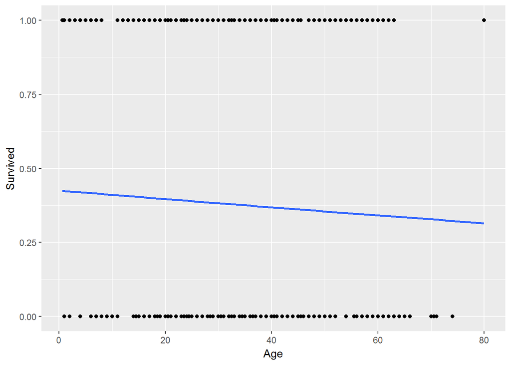

```r
library(ggplot2)
ggplot(training_set, aes(x=Age, y=Survived)) + geom_point() + stat_smooth(method = "glm", method.args = list(family ="binomial"), se=FALSE)
```

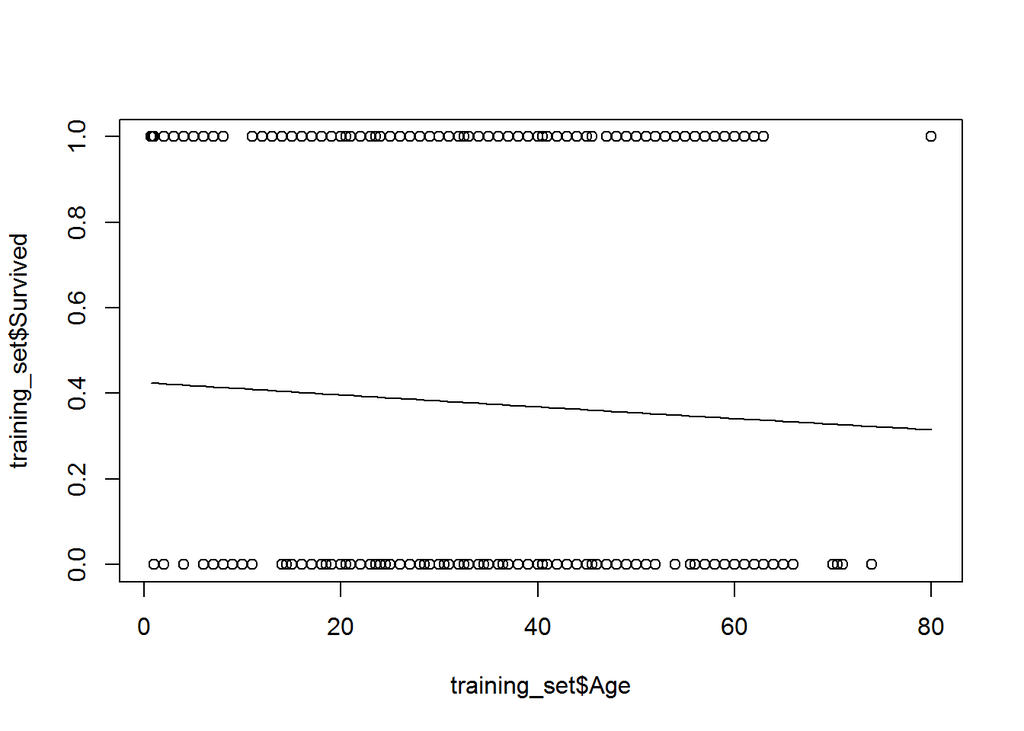

```r
plot(training_set$Age, training_set$Survived)
curve(predict(classifier, data.frame(Age=x), type='response'), add=TRUE)
```

We can chose an other predict with Age, Sex and Pclass

```r
library(caTools)
set.seed(123)
split = sample.split(data$Survived, SplitRatio = 0.75)
training_set = subset(data, split == TRUE)
test_set = subset(data, split == FALSE)
classifier <- glm(Survived ~ Age + Sex + Pclass , family = binomial, data=training_set)
summary(classifier)
```

```
##
## Call:
## glm(formula = Survived ~ Age + Sex + Pclass, family = binomial,
##     data = training_set)
##
## Deviance Residuals:
##     Min       1Q   Median       3Q      Max
## -2.5868  -0.6280  -0.4175   0.6190   2.5748
##
## Coefficients:
##              Estimate Std. Error z value Pr(>|z|)
## (Intercept)  4.495849   0.521658   8.618  < 2e-16 ***
## Age         -0.028434   0.008187  -3.473 0.000515 ***
## Sexmale     -2.651933   0.213829 -12.402  < 2e-16 ***
## Pclass      -1.129095   0.141499  -7.980 1.47e-15 ***
## ---
## Signif. codes:  0 '***' 0.001 '**' 0.01 '*' 0.05 '.' 0.1 ' ' 1
##
## (Dispersion parameter for binomial family taken to be 1)
##
##     Null deviance: 889.27  on 667  degrees of freedom
## Residual deviance: 597.85  on 664  degrees of freedom
## AIC: 605.85
##
## Number of Fisher Scoring iterations: 4
```

Now the p-value is lower than 0,05 so the predict (Sex, Age and Pclass) is significant.

We can do a confusion matrix to evaluate the predictions.

```r
pred=predict(classifier,training_set,type='response')
mat<-ifelse(pred>0.5,1,0)
#Pclass
table(mat,training_set[,3])
```

```
##
## mat   1   2   3
##   0  73  85 275
##   1  85  61  89
```

```r
#Sex
table(mat,training_set[,5])
```

```
##
## mat female male
##   0     15  418
##   1    225   10
```

```r
#Age : 0 for people<40, else 1
t=ifelse(training_set[,6]>40,1,0)
table(mat,t)
```

```
##    t
## mat   0   1
##   0 331 102
##   1 202  33
```

## Linear Discriminant Analysis

Now, we will do a LDA model of Survived in function of Age and Sex.

```r
library(MASS)
classifier.lda <- lda(Survived~Age+Sex, data=training_set)
classifier.lda
```

```
## Call:
## lda(Survived ~ Age + Sex, data = training_set)
##
## Prior probabilities of groups:
##         0         1
## 0.6167665 0.3832335
##
## Group means:
##        Age   Sexmale
## 0 30.05583 0.8543689
## 1 28.92480 0.2968750
##
## Coefficients of linear discriminants:
##                   LD1
## Age     -0.0004221826
## Sexmale -2.5212994620
```

```r
classifier.lda$prior
```

```
##         0         1
## 0.6167665 0.3832335
```

This shows only 38% people survived.

```r
classifier.lda$means
```

```
##        Age   Sexmale
## 0 30.05583 0.8543689
## 1 28.92480 0.2968750
```

We can see the most people who didn’t survive are men (85%)

```r
pred_lda=predict(classifier.lda,test_set[c(5,6)],type='response')
str(pred_lda)
```

```
## List of 3
##  $ class    : Factor w/ 2 levels "0","1": 1 1 1 2 2 1 1 2 1 1 ...
##  $ posterior: num [1:223, 1:2] 0.879 0.88 0.877 0.172 0.172 ...
##   ..- attr(*, "dimnames")=List of 2
##   .. ..$ : chr [1:223] "5" "7" "8" "10" ...
##   .. ..$ : chr [1:2] "0" "1"
##  $ x        : num [1:223, 1] -0.908 -0.916 -0.894 1.622 1.622 ...
##   ..- attr(*, "dimnames")=List of 2
##   .. ..$ : chr [1:223] "5" "7" "8" "10" ...
##   .. ..$ : chr "LD1"
```

We can compute a confusion matrix :

```r
y_pred<-ifelse(pred>0.5,1,0)
y=y_pred[1:223]

table(pred_lda$class,y)
```

```
##    y
##       0   1
##   0 100  49
##   1  45  29
```

## Conclusion

With this two methods we showed the survived of people are in majority women or young.